# Local Dependence

## Five Blocks Models

I want to make sure whether in the case of five blocks, my assumption of `getting stuck` between one or two blocks holds or not. It just imitates the previous block model with more number of blocks, expecting that the local optimal scale is stuck much ealier.

$A = \left[ \begin{array}{c|c|c|c|c} \color{red}{0.30} & 0.05 & 0.05 & 0.05 & 0.05 \\ \hline 0.05 & \color{red}{0.30} & 0.05 & 0.05 & 0.05 \\ \hline 0.05 & 0.05 & \color{red}{0.30} & 0.05 & 0.05 \\ \hline 0.05 & 0.05 & 0.05 & \color{red}{0.30} & 0.05 \\ \hline 0.05 & 0.05 & 0.05 & 0.05 & \color{red}{0.30} \end{array} \right]$

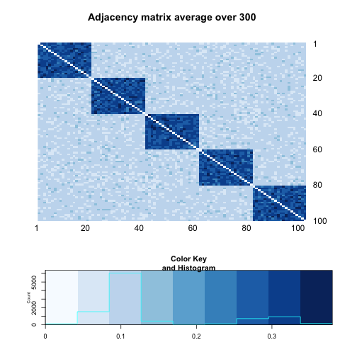

and corresponding nodes’ attributes are following such Bernoulli models :

$X = \left[ \begin{array}{c|c|c|c|c} Bern(0.35) & & & & \\ \hline & Bern(0.65) & & & \\ \hline & & Bern(0.50) & & \\ \hline & & & Bern(0.65) & \\ \hline & & & & Bern(0.35) \end{array} \right]$

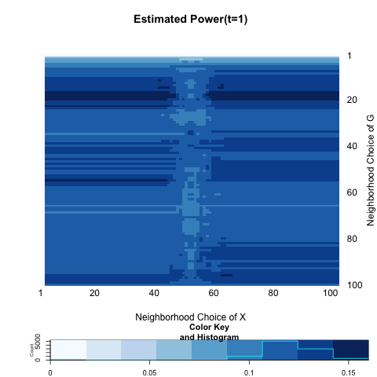

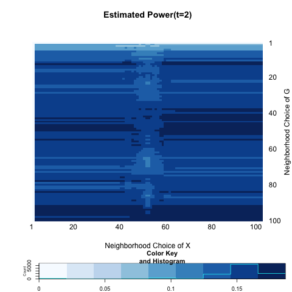

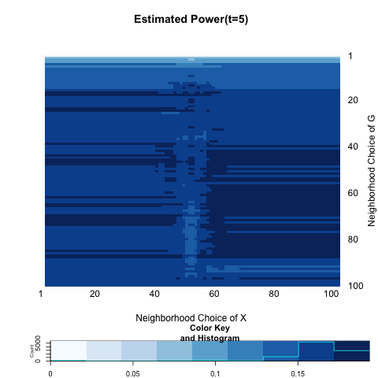

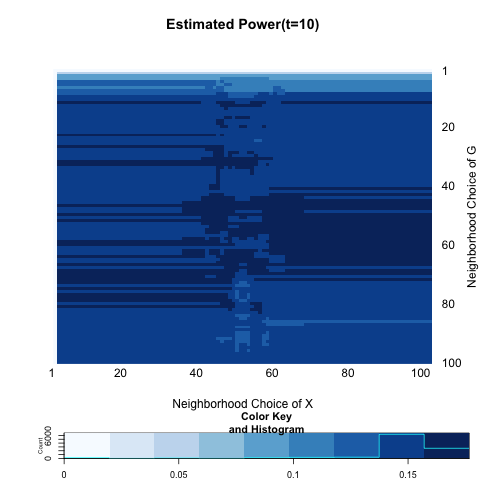

|  | t=1 | t=2 | t=5 | t=10 |
| --- | --- | --- | --- | --- |
| global test | 0.12 | 0.17 | 0.16 | 0.15 |
| local optimal | 0.16 | 0.19 | 0.19 | 0.18 |

It does not show any particular pattern. This shows that estimated power deceases as the number of blocks increases and the number of individuals within the block decreases.

$X = \left[ \begin{array}{c|c|c|c|c} Bern(0.35) & & & & \\ \hline & Bern(0.65) & & & \\ \hline & & Bern(0.50) & & \\ \hline & & & Bern(0.65) & \\ \hline & & & & Bern(0.35) \end{array} \right]$

$A = \left[ \begin{array}{c|c|c|c|c} \color{red}{0.50} & 0.05 & 0.05 & 0.05 & 0.05 \\ \hline 0.05 & \color{red}{0.50} & 0.05 & 0.05 & 0.05 \\ \hline 0.05 & 0.05 & \color{red}{0.50} & 0.05 & 0.05 \\ \hline 0.05 & 0.05 & 0.05 & \color{red}{0.50} & 0.05 \\ \hline 0.05 & 0.05 & 0.05 & 0.05 & \color{red}{0.50} \end{array} \right]$

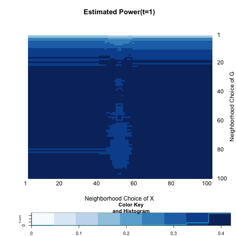

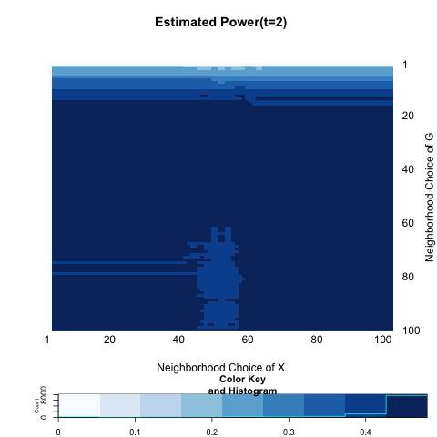

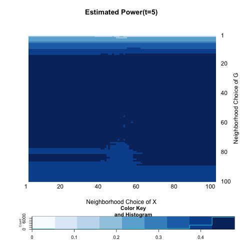

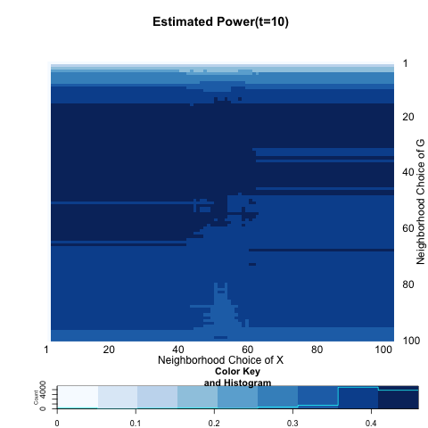

|  | t=1 | t=2 | t=5 | t=10 |
| --- | --- | --- | --- | --- |
| global test | 0.40 | 0.43 | 0.39 | 0.33 |
| local optimal | 0.42 | 0.48 | 0.48 | 0.46 |

As diffusion time increases, power difference between the local and globla increases.